# Deep Potato - the hyperspectral imagery of potato leaves with reference agronomic measurements dataset: towards potato physiological features modelling

### Authors:

- Ruszczak Bogdan 1 QZ Solutions Sp. z o.o., Opole, Poland 2 Department of Electrical, Control and Computer Engineering, Opole University of Technology, Opole, Poland
- Dominika Boguszewska-Mańkowska
  - Plant Breeding and Acclimatization Institute - National Research Institute Jadwisin, Poland
- link to the repository https://data.mendeley.com/datasets/xn2wy75f8m
- to cite this database please refer to the paper:
  - Ruszczak B., Boguszewska-Mańkowska D.: Deep Potato - the hyperspectral imagery of potato leaves with reference agronomic measurements dataset: towards potato physiological features modelling, Data in Brief, vol. 42, June 2022, 108087*, doi.org/10.1016/j.dib.2022.108087*

### Description

- the dataset contains 8 high resolution, 150 band, hyperspectral orthophotomaps for deep learning modelling
  - 8 full resolution orthophotomaps (ENVI format - 8 .hdr and .bsq files),
  - 80 extracted, masked hyperspectral images (numpy array format - 80 .npz files),
- for a reference, there are two table supplemented, with 60 laboratory examination results and 74 physiological measurements, based on collected plants' material (2 .geojson files).
- the file "CHESS_FOLDS.CSV" containes four additional columns: SPAD_fold, FvFm_fold, PI_fold, RWC_fold. Each column with "_fold" suffix indicates train (0) and test (1) sets for parameters (i.e. SPAD_fold with zeros denotes train samples for SPAD measurements). Those folds has been presented in the publication: Ruszczak B., Nalepa J.: Unbiasing the Estimation of Chlorophyll from Hyperspectral Images: A Benchmark Dataset, Validation Procedure and Baseline Results.

# Physiological measurements

(3 examples)

| Sample_Index | Flight_Date | Field | RWC | SPAD | FvFm | PI |
| --- | --- | --- | --- | --- | --- | --- |
| 5 | 2020-06-30T12:24:00 | 17 | 86.1 | 43.42 | 0.76 | 1.38 |
| 15 | 2020-06-30T12:27:00 | 3 | 82.9 | 33.42 | 0.76 | 0.98 |
| 30 | 2020-07-14T12:05:00 | 6 | 85.9 | 31.92 | 0.77 | 1.51 |

| Sample_Index | Map_Filename | Soil_Moisture | H200 | T200 | Tg5 | Tg10 | Tg20 | Tg50 | Variety | Group | Fold | geometry |
| --- | --- | --- | --- | --- | --- | --- | --- | --- | --- | --- | --- | --- |
| 5 | 2020-06-30_10_24_15_ihar_22_g1.hdr | 14.35 | 99 | 16.0 | 19.9 | 20.7 | 21.7 | 21.0 | 0 | 1 | 3 | POLYGON ((21.04453 52.48342, 21.04455 52.48342... |
| 15 | 2020-06-30_10_27_39_ihar_25_g2.hdr | 4.15 | 99 | 16.0 | 19.9 | 20.7 | 21.7 | 21.0 | 0 | 2 | -1 | POLYGON ((21.04285 52.48361, 21.04288 52.48361... |
| 30 | 2020-07-14_10_05_31_ihar_15_g2.hdr | 7.39 | 96 | 10.4 | 16.5 | 17.4 | 18.4 | 18.4 | 0 | 2 | 2 | POLYGON ((21.04298 52.48358, 21.04301 52.48358... |

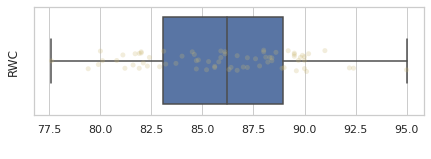

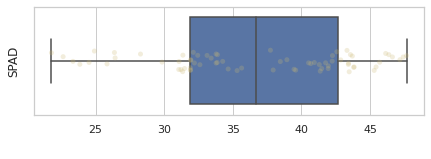

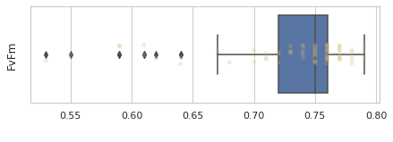

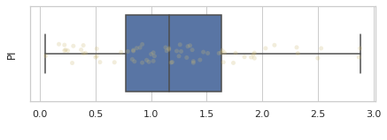

```
Additional parameters: ['Sample_Index', 'Field', 'Variety', 'Group', 'H200', 'T200', 'Tg5', 'Tg10', 'Tg20', 'Tg50', 'Soil_Moisture', 'Fold', 'Flight_Date', 'Map_Filename', 'geometry']
```

# Lab Measurements

(3 examples)

| Sample_Index | Plant_Height | Number_Of_Stems | Stem_Mass | Stem_Dry_Mass | Number_Of_Tubers | Tuber_Fresh_Mass | Tuber_Dry_Mass | Leaf_Fresh_Mass | Leaf_Dry_Mass | Assimilation_Area | LAI | Starch_Content |
| --- | --- | --- | --- | --- | --- | --- | --- | --- | --- | --- | --- | --- |
| 5 | 78 | 3 | 499.71 | 5.88 | 16 | 445.14 | 16.38 | 993.62 | 8.32 | 12294.0 | 4.92 | 9.50 |
| 15 | 56 | 8 | 326.74 | 5.38 | 21 | 543.93 | 18.04 | 703.08 | 9.00 | 9349.0 | 3.74 | 11.90 |
| 30 | 66 | 8 | 411.14 | 6.94 | 17 | 820.77 | 22.89 | 550.34 | 10.20 | 7276.0 | 2.91 | 16.61 |

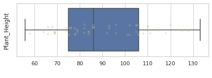

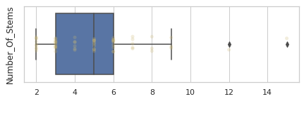

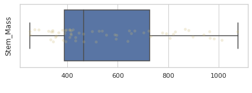

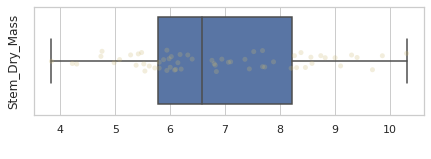

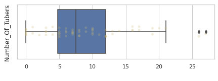

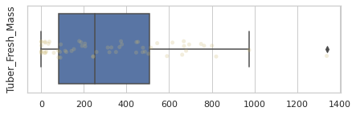

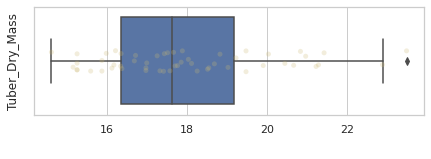

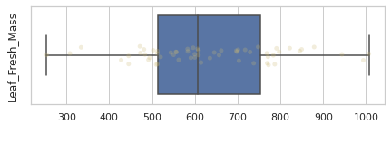

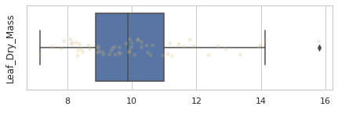

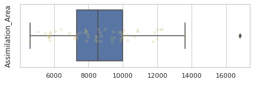

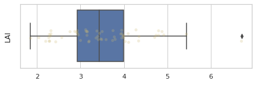

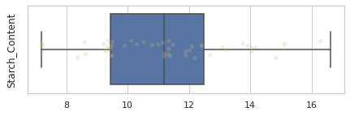

```
Additional parameters: ['Sample_Index', 'Field', 'Variety', 'Group', 'H200', 'T200', 'Tg5', 'Tg10', 'Tg20', 'Tg50', 'Soil_Moisture', 'Fold', 'Flight_Date', 'Map_Filename', 'geometry']
```

# Sample images extracted from provided maps

(3 examples)

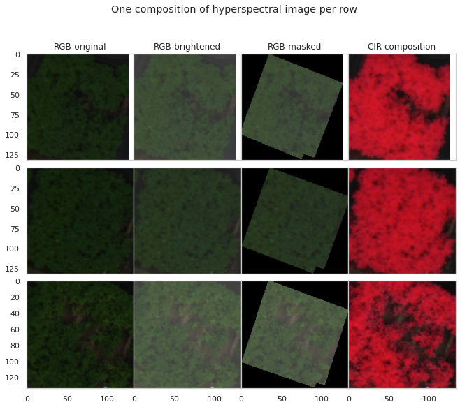

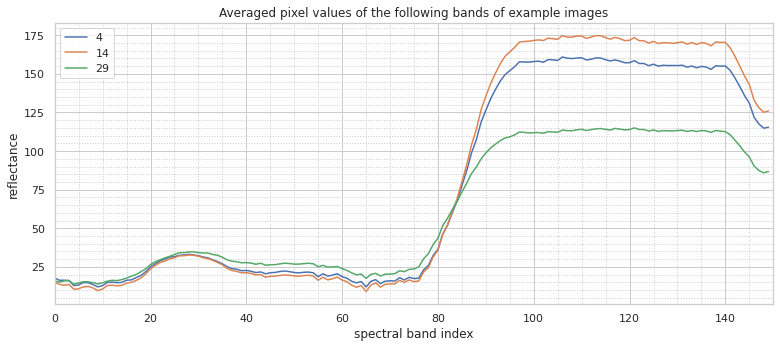

# Fields and groups arrangement

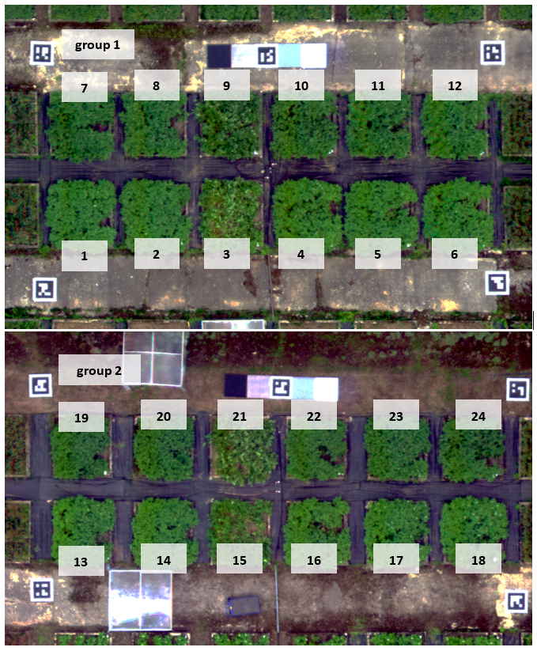